# Megabummer

### Data Science BIO 260 Final Project, Spring 2016

##### Allison Blajda, Leo Brown, and Emily Lisker

### Overview and Motivation

Social media users leave digital traces that can be leveraged to guide consumer purchasing decisions. Twitter users, in particular, provide temporal data that can be analyzed to develop a more precise understanding of users’ perspectives or sentiments about a service, company, or product. This information, in turn, can be shared with the public to allow customers to make decisions based on crowd-sourced knowledge. It may also even help the service provider understand how they can improve their services.

Imagine it is Friday in July and you are finishing up a long week at the office. The clock reads 4:00pm and you quickly race to pack up your work station. You need to get downtown to catch the 5pm MegaBus from NYC to Washington, DC. You are ready to start the weekend and have plans at 10pm in downtown DC. You naviate the NYC subway and break a sweat walking quickly down 34th Street, hoping that you are early enough to score an aisle seat. As you approach the bus stop you come into view of your worst nightmare: a line with hundreds of angry Megabus passengers waiting with no bus in sight. As you walk towards the end of the line another passenger mentions that the 3:30pm bus hasn’t arrived yet. A Megabus employee tells you he has no idea when the 5pm bus will depart (“Who knows…”). It is 90 degrees, you are sweating profusely, and you will surely miss your evening plans. You feel helpless. A wronged consumer with no recourse. Then you remember a social media site called Twitter…

### Related Work:

Sentiment analysis performed by our very own TA, David Robinson provided initial guiding inspiration for this this work (https://github.com/juliasilge/tidytext).

We were also inspired by sentiment analysis of Twitter data related to current events. Some examples of other analyses that we explored includes: http://www.wired.com/2015/02/best-worst-public-transit-systems-according-twitter/#slide-2 and https://medium.com/mit-media-lab/introducing-tonar-3bf161cba369#.gixrkibqj

### Initial Questions:

As a team, we were originally interested in building a predictive model for Megabus experience based on time of day, location and bus route. Based on the data that we were able to collect from Twitter, these questions evolved to focus on the relationship between Megabus passenger sentiment, the volume of Megabus tweets, day of the week, whether the tweet was posted on a weekday (Monday-Thursday) or a weekend (Friday-Sunday), and month of the year.

The questions we have answered as part of this analysis include the following: 1. How can we most effectively scrape Twitter for data related to Megabus sentiment? 2. What is overall Megabus sentiment and volume of Megabus tweets during the period from January 1, 2015 to April 1, 2016? 3. How does Megabus sentiment and volume of tweets differ based on day of the week and month of the year? 4. What is the realtionship between volume of Megabus tweets on a given day and the overall sentiment we expect to see?

### Data:

#### Data Scraping and Tidying

We aimed to obtain historical tweet data in order to observe trends in tweet volume and sentiment over time and identify associations with factors such as time of year, month, and day. Since there are many factors influencing tweet volume and sentiment, we wished to obtain the largest possible data set.

Initially, we set up an app (actually, three apps, one for each of us) on the Twitter API that obtained tweets including the word “megabus.” This was a great learning experience; we remember fondly this effort as our first true collaboration on git; our first exposure to the Twitter API; when we first set up an .Rprofile to store key sensitive variables; and the first tweet data we obtained. However, it became clear that the Twitter API would only provide us with tweets from the last week. This was insufficient for most of the trends we wished to consider.

A google search led us to [Jefferson Henrique’s python package GetOldTweets-python](https://github.com/Jefferson-Henrique/GetOldTweets-python). This package enabled us to obtain tweets from any date (at least, we did not encounter a date that was inaccessible). The original package can be run to print tweets in the terminal. We modified the script so that it would print tweets to a csv file. As a result we obtained over 100,000 tweets from January 1, 2015 through April 1, 2016 containing the word “megabus.”

We conducted much of our exploratory analysis using only tweets from the first three months of 2015. Though some questions of interest pertained to the entire 15-month period, we wanted to make sure the data frame was not too large during our exploratory phase. There was initially some evidence that the data frame was too large because some commands were slow. However, it was later identified that the only time-consuming command was an inefficiently written for loop that created several new columns. This was improved to a series of mutate() functions, and since then, wrangling the data frames takes only a few seconds from start to finish.

In order to look at variations in sentiment over days and time, we parsed the combined date and time variable into two new variables, containing just date and time information. We also used the months() function to create a month column and the weekdays() function to create a column that identified the tweet day and another to identify the tweet’s status binary weekend status, with Friday counting as part of the weekend.

We cleaned the data using dplyr and the tidytext package, in order to help with the text mining tasks necessary for sentiment analysis, available here: https://github.com/juliasilge/tidytext.

#### Loading all necessary libraries

```r
library(dplyr)
```

```r
library(ggplot2)
library(ggthemes)
library(readr)
library(devtools)
library(tidytext)
library(tidyr)
library(readr)
library(data.table)
library(Hmisc)
library(tm)
library(SnowballC)
library(wordcloud)
library(RColorBrewer)

library(devtools)

library(igraph)
library(ggraph)
library(gapminder)
```

#### Loading and wrangling the full data set

```r
#Increase digits so that the many-digit tweet id does not cause a problem.
options(digits = 22)
tweets_df_all <- read_csv("Jan_2015-April_2016.csv")
#Change the column names.
names(tweets_df_all) <- c("id","username","text","date","geo","retweets","favorites","mentions","hashtags")

#get a subset of random lines from the full set to work with:
#tweets_df_all <- tweets_df_all[sample(1:nrow(tweets_df_all), 10000, replace=FALSE),]

tweets_df_all <- tweets_df_all %>%
  mutate(time=format(date, format="%H:%M:%S")) %>%
  mutate(date2 = format(date, format="%m-%d-%y")) %>%
  mutate(month = months(as.Date(date2,'%m-%d-%y'))) %>%
  mutate(weekend = weekdays(as.Date(date2,'%m-%d-%y'))) %>%
  mutate(weekend_binary = ifelse(weekend == "Saturday"|weekend=="Sunday"|weekend=="Friday", 1, 0)) %>%
  filter(date2 != "12-31-14") %>%
  filter(date < "2016-04-01")
# filter out duplicates
tweets_df_all <- tweets_df_all %>%
  distinct(id)
#nrow(tweets_df_all)
tweets_df_all <- tweets_df_all %>%
  distinct(text)
```

#### Exploring the data set, part 1 (prior to sentiment analysis)

```r
# explore number of tweets per user including megabus handles
prolific_tweeters_all <- tweets_df_all %>%
  group_by(username) %>%
  summarise(tweets = n()) %>%
  arrange(desc(tweets))

# filter out tweets from megabus operators
tweets_df_all = tweets_df_all[!grepl("megabus|megabusuk|MegabusHelp|megabusit|megabusde|megabusGold", tweets_df_all$username),]
prolific_tweeters_filtered <- tweets_df_all %>%
  group_by(username) %>%
  summarise(tweets = n()) %>%
  arrange(desc(tweets))
```

### Exploratory Analysis

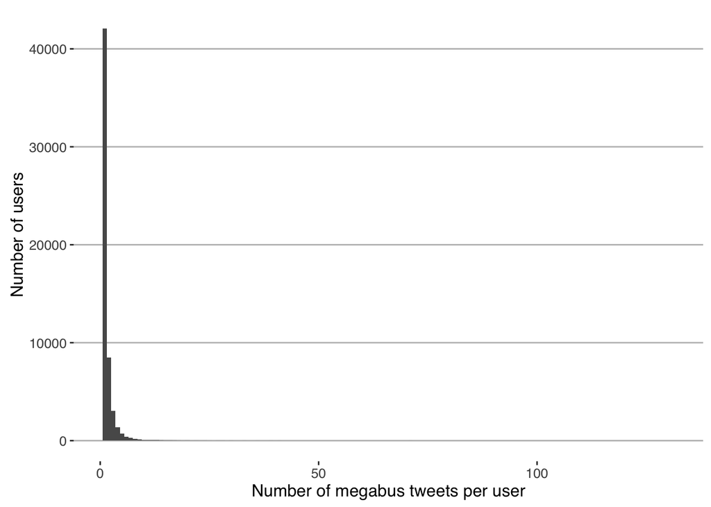

```r
# Histogram of number of tweets
ggplot(filter(prolific_tweeters_filtered, tweets>0), aes(tweets)) +
  geom_histogram(binwidth = 1) + xlab("Number of megabus tweets per user") + ylab("Number of users") + theme_hc()
```

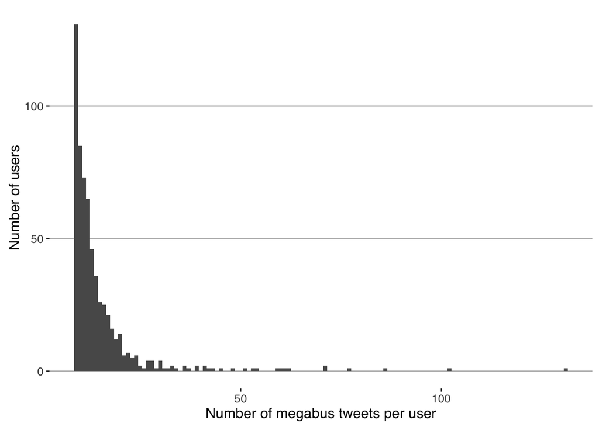

```r
# Histogram of number of tweets, for users with more than 8 tweets so that we can get a closer look at the more prolific tweeters
ggplot(filter(prolific_tweeters_filtered, tweets>8), aes(tweets)) +
  geom_histogram(binwidth = 1) + xlab("Number of megabus tweets per user") + ylab("Number of users") + theme_hc()
```

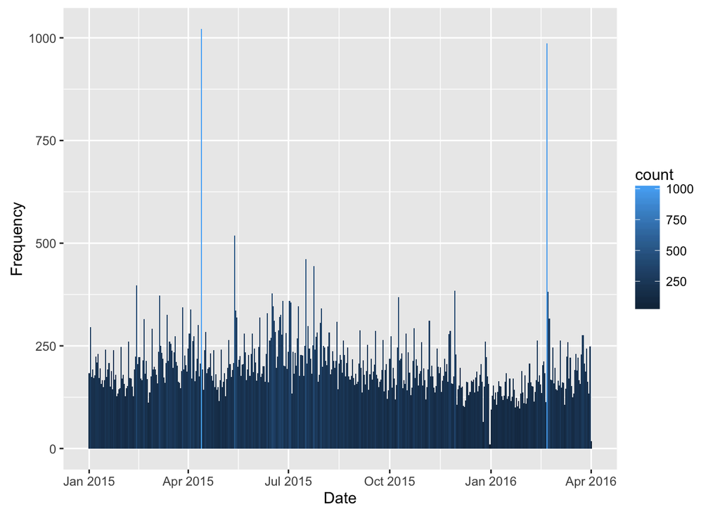

```r
#Tweets per day
ggplot(data=tweets_df_all, aes(x=as.Date(date2,'%m-%d-%y'))) +
  geom_histogram(aes(fill=..count..), binwidth=1) +
  scale_x_date("Date") +
  scale_y_continuous("Frequency")
```

```r
#The outlying days with high tweet volume are:
tweets_df_all %>% group_by(date2) %>% count(date2, sort = TRUE) %>% filter(n>500)
```

```
## Source: local data frame [3 x 2]
##
##      date2     n
##      (chr) (int)
## 1 04-13-15  1022
## 2 02-21-16   986
## 3 05-13-15   519
```

```r
#The outlying days with low tweet volume are:
tweets_df_all %>% group_by(date2) %>% count(date2, sort = TRUE) %>% filter(n<100)
```

```
## Source: local data frame [5 x 2]
##
##      date2     n
##      (chr) (int)
## 1 01-27-16    97
## 2 01-01-16    95
## 3 12-25-15    65
## 4 04-01-16    18
## 5 12-31-15    10
```

On each of the outlying days for high tweet volume, there were significant news stories about Megabus.

*February 21, 2016: The Day My Megabus Caught Fire*

#### Sentiment Analysis

Like most sentiment analyses, we relied on a lexicon of positive and negative words. We started with the Bing lexicon in the tidytext package in the sentiment dataset (described here in more detail https://www.cs.uic.edu/~liub/). This lexicon has been compiled over the past 12 years by researchers at the University of Illinois at Chicago.

After initial review of the Bing lexicon, we realized that we need to supplement the list of positive and negative words in order to capture the extent of Megabus transportation-specific sentiments. We added a total of 57 sentiment related to Megabus and transportation experience. These additional negative and positive words were identified by manually reviewing a random sample from 2900 tweets containing the keyword, “megabus” queried on 4/20/2016, following methods similar to those described here: http://www.wired.com/2015/02/best-worst-public-transit-systems-according-twitter/. This review comparing the Bing lexicon with Megabus tweets also revealed that a few sentiments already in the lexicon needed to be recorded or removed. These included: changing “uneventful” from negative to positive, reversing “cheap” from negative to positive given Megabus’s platform as a cheap transportation provider, and the removal of “like” which could be positive or negative and is probaby slang.

```r
by_word <- tweets_df_all %>%
  dplyr::select(text, id, date, date2, time, weekend, weekend_binary, month) %>%
  unnest_tokens(word, text)

# look at most commonly tweeted words
by_word_count <- by_word %>%
  count(word, sort = TRUE)
head(by_word_count)
```

```
## Source: local data frame [6 x 2]
##
##      word     n
##     (chr) (int)
## 1 megabus 95116
## 2     the 51102
## 3      to 43150
## 4       a 34032
## 5      on 30676
## 6       i 25996
```

```r
megabus_lexicon <- read_csv("megabus_lexicon.csv")


# create new dataframe of bing and megabummer sentiments
bing_megabus <- megabus_lexicon %>%
  filter(lexicon %in% c("bing","megabummer")) %>%
  dplyr::select(-score)
head(bing_megabus %>% filter(lexicon=="megabummer"))
```

```
## Source: local data frame [6 x 4]
##
##      NA       word sentiment    lexicon
##   (int)      (chr)     (chr)      (chr)
## 1 20207 uneventful  positive megabummer
## 2 23166    working  negative megabummer
## 3 23167      cried  negative megabummer
## 4 23168 neveragain  negative megabummer
## 5 23169     crying  negative megabummer
## 6 23170        pee  negative megabummer
```

```r
# join tweets with sentiment and add score column
mb_sentiment <- by_word %>%
  inner_join(bing_megabus) %>%
  mutate(score = ifelse(sentiment == "positive", 1, -1))
head(mb_sentiment %>% dplyr::select(id,word,sentiment,score))
```

```
## Source: local data frame [6 x 4]
##
##                   id     word sentiment score
##                (dbl)    (chr)     (chr) (dbl)
## 1 550802761462603776    smash  negative    -1
## 2 550798250463473664  working  negative    -1
## 3 550798250463473664     love  positive     1
## 4 550798250463473664     work  positive     1
## 5 550797004344152064 struggle  negative    -1
## 6 550797004344152064  waiting  negative    -1
```

```r
# calculate score for each tweet
dt <- data.table(mb_sentiment)

#build data set for sentiment analysis containing data on each tweet including sentiment score
mb_sentiment_tweet <- unique(dt[,list(score_tweet = sum(score), freq = .N, date, weekend_binary, date2, weekend, month), by = c("id")] )
tweets_df_all_joiner <- tweets_df_all %>% dplyr::select(id,text)
mb_sentiment_tweet <- left_join(mb_sentiment_tweet,data.table(tweets_df_all_joiner),by="id")
head(mb_sentiment_tweet)
```

```
##                   id score_tweet freq                date weekend_binary
## 1 550520819819220992           0    2 2015-01-01 00:16:06              0
## 2 550522977519824896           2    2 2015-01-01 00:24:40              0
## 3 550525690983239680           1    1 2015-01-01 00:35:27              0
## 4 550536610228731904          -2    2 2015-01-01 01:18:51              0
## 5 550574314970697664           0    2 2015-01-01 03:48:40              0
## 6 550579369366663168          -1    1 2015-01-01 04:08:45              0
##      date2  weekend   month
## 1 01-01-15 Thursday January
## 2 01-01-15 Thursday January
## 3 01-01-15 Thursday January
## 4 01-01-15 Thursday January
## 5 01-01-15 Thursday January
## 6 01-01-15 Thursday January
##                                                                                                                                           text
## 1 @megabus regarding bad weather, whats your ticket refund policy? As my bus from DC to Toronto is en route back to DC after philadelphia stop
## 2 Photo clearly shows bus listing to the right. Megabus on Borman Expressway taken out of service, police say: http:// bit.ly/14eeRha via @nwi
## 3                                                             My bus ticket home from the Toronto airport for Pax East is $1. I love Megabus .
## 4                                                                                      So anyway megabus is a group of shit eaters never again
## 5 Best exchange of 2014 on a Megabus @kaoskelley : [laughing] "Come on, man." @SoxHawksNBulls: [angrily] " 'Come on' my ass!!!....Goddamn it."
## 6                                Megabus Problems Continue After Bus Placed Out of Service in Lake County #Indianapolis http:// bit.ly/1ENSmzF
```

```r
#Creating data table of calendar dates, including weekend status, day of week (column name weekend), month, and tweet frequency and sentiment
mb_sentiment_date <- unique(mb_sentiment_tweet[,list(score_date = round(mean(score_tweet),2), freq = .N, weekend_binary, weekend, month), by = c("date2")] )
mb_sentiment_date <- mb_sentiment_date %>% filter(freq<500)
head(mb_sentiment_date)
```

```
##      date2                score_date freq weekend_binary  weekend   month
## 1 01-01-15 -0.4699999999999999733546  114              0 Thursday January
## 2 01-02-15 -0.4299999999999999933387  174              1   Friday January
## 3 01-03-15 -0.4199999999999999844569  106              1 Saturday January
## 4 01-04-15 -0.2500000000000000000000  115              1   Sunday January
## 5 01-05-15 -0.1900000000000000022204  102              0   Monday January
## 6 01-06-15 -0.3200000000000000066613  106              0  Tuesday January
```

```r
#Creating data table of calendar dates and tweet frequency and sentiment with holiday status (including federal holidays, Valentine's Day, and Halloween)
mb_sentiment_holidays <- mb_sentiment_date %>%
  mutate(holiday = ifelse(date2 == "01-01-15" |
                            date2 == "01-19-15" |
                            date2 == "02-14-15" |
                            date2 == "02-16-15" |
                            date2 == "05-25-15" |
                            date2 == "09-07-15" |
                            date2 == "10-12-15" |
                            date2 == "10-31-15" |
                            date2 == "11-11-15" |
                            date2 == "11-26-15" |
                            date2 == "12-25-15" |
                            date2 == "01-01-16" |
                            date2 == "01-18-16" |
                            date2 == "02-14-16" |
                            date2 == "02-15-16",1,
                          0
                            ))
head(mb_sentiment_holidays)
```

```
##      date2                score_date freq weekend_binary  weekend   month
## 1 01-01-15 -0.4699999999999999733546  114              0 Thursday January
## 2 01-02-15 -0.4299999999999999933387  174              1   Friday January
## 3 01-03-15 -0.4199999999999999844569  106              1 Saturday January
## 4 01-04-15 -0.2500000000000000000000  115              1   Sunday January
## 5 01-05-15 -0.1900000000000000022204  102              0   Monday January
## 6 01-06-15 -0.3200000000000000066613  106              0  Tuesday January
##   holiday
## 1       1
## 2       0
## 3       0
## 4       0
## 5       0
## 6       0
```

#### Exploring the data set, part 2 (sentiment analysis)

The describe() function in Hmisc helped us see how tweet sentiment scores are distributed. In particular, we noticed that the distribution of *by tweet* sentiment scores was similar to the distribution of *by date* sentiment scores (the average sentiment score for that day). We therefore focused our analysis on the *by date* sentiment scores because it was a convenient bin for looking at trends over time and for moderating the considerable variance. The *by date* sentiment score gives a sense for the overall level of sentiment on any given day, which is what we ultimately decided to consider as our main outcome.

```r
describe(mb_sentiment_tweet)
```

```
## mb_sentiment_tweet
##
##  9  Variables      51683  Observations
## ---------------------------------------------------------------------------
## id
##         n   missing    unique      Info      Mean       .05       .10
##     51683         0     51682         1  6.29e+17 5.591e+17 5.679e+17
##       .25       .50       .75       .90       .95
## 5.887e+17 6.248e+17 6.666e+17 6.999e+17 7.076e+17
##
## lowest : 5.505e+17 5.505e+17 5.505e+17 5.505e+17 5.506e+17
## highest: 7.158e+17 7.158e+17 7.158e+17 7.158e+17 7.158e+17
## ---------------------------------------------------------------------------
## score_tweet
##       n missing  unique    Info    Mean     .05     .10     .25     .50
##   51683       0      18    0.92 -0.3476      -2      -2      -1      -1
##     .75     .90     .95
##       1       1       2
##
##           -10 -9 -8 -7 -6 -5  -4   -3   -2    -1    0     1    2   3   4
## Frequency   1  1  2  1 26 91 406 1750 6606 19545 5917 13307 3246 641 122
## %           0  0  0  0  0  0   1    3   13    38   11    26    6   1   0
##            5 6 7
## Frequency 18 2 1
## %          0 0 0
## ---------------------------------------------------------------------------
## freq
##       n missing  unique    Info    Mean     .05     .10     .25     .50
##   51683       0      10    0.79   1.623       1       1       1       1
##     .75     .90     .95
##       2       3       3
##
##               1     2    3    4   5  6  7 8 9 10
## Frequency 29619 14681 5291 1568 419 72 23 6 3  1
## %            57    28   10    3   1  0  0 0 0  0
## ---------------------------------------------------------------------------
## date
##                   n             missing              unique
##               51683                   0               51599
##                Info                Mean                 .05
```

[output cut: 31 more lines]

```
##
##           April August December February January July June March  May
## Frequency  4291   3706     2597     6420    5489 4487 3910  7161 3938
## %             8      7        5       12      11    9    8    14    8
##           November October September
## Frequency     3182    3448      3054
## %                6       7         6
## ---------------------------------------------------------------------------
## text
##       n missing  unique
##   51683       0   51683
##
## lowest : _ fuck you Chicago Amtrak agents. FUCK YOU. (@Megabus Chicago to Ann Arbor in Chicago, IL) https://www. swarmapp.com/c/631H6tDGuxb     - " Is that the MeggggaaaBus!???" - " Yes that's the MegggaaaBus!!! " Sun Valley guys kill me . Saluting the MegaBus Ai #ResLife       - #tuu i #yoo - 19…
## highest: Zero sleep, back pain, and a stranger practically spooning you. Always a fun night on the megabus .                                    Zoe just turned Yeah by Usher off and am off to get a megabus me no longer friends not worth it                                        Zola must have a h…
## ---------------------------------------------------------------------------
```

```r
describe(mb_sentiment_date)
```

```
## mb_sentiment_date
##
##  6  Variables      455  Observations
## ---------------------------------------------------------------------------
## date2
##       n missing  unique
##     455       0     455
##
## lowest : 01-01-15 01-01-16 01-02-15 01-02-16 01-03-15
## highest: 12-27-15 12-28-15 12-29-15 12-30-15 12-31-15
## ---------------------------------------------------------------------------
## score_date
##       n missing  unique    Info    Mean     .05     .10     .25     .50
##     455       0      89       1 -0.3162  -0.623  -0.546  -0.430  -0.320
##     .75     .90     .95
##  -0.190  -0.074   0.000
##
## lowest : -1.12 -0.95 -0.86 -0.77 -0.76
## highest:  0.10  0.14  0.16  0.19  0.27
## ---------------------------------------------------------------------------
## freq
##       n missing  unique    Info    Mean     .05     .10     .25     .50
##     455       0     141       1   110.4      61      70      86     104
##     .75     .90     .95
##     129     162     181
##
## lowest :   8  35  48  49  50, highest: 227 230 253 273 284
## ---------------------------------------------------------------------------
## weekend_binary
##       n missing  unique    Info     Sum    Mean
##     455       0       2    0.73     195  0.4286
## ---------------------------------------------------------------------------
## weekend
##       n missing  unique
##     455       0       7
##
##           Friday Monday Saturday Sunday Thursday Tuesday Wednesday
## Frequency     66     64       65     64       66      65        65
## %             15     14       14     14       15      14        14
## ---------------------------------------------------------------------------
## month
##       n missing  unique
##     455       0      12
##
##           April August December February January July June March May
## Frequency    30     31       31       56      62   31   30    62  31
## %             7      7        7       12      14    7    7    14   7
##           November October September
## Frequency       30      31        30
## %                7       7         7
## ---------------------------------------------------------------------------
```

```r
describe(mb_sentiment_holidays)
```

```
## mb_sentiment_holidays
##
##  7  Variables      455  Observations
## ---------------------------------------------------------------------------
## date2
##       n missing  unique
##     455       0     455
##
## lowest : 01-01-15 01-01-16 01-02-15 01-02-16 01-03-15
## highest: 12-27-15 12-28-15 12-29-15 12-30-15 12-31-15
## ---------------------------------------------------------------------------
## score_date
##       n missing  unique    Info    Mean     .05     .10     .25     .50
##     455       0      89       1 -0.3162  -0.623  -0.546  -0.430  -0.320
##     .75     .90     .95
##  -0.190  -0.074   0.000
##
## lowest : -1.12 -0.95 -0.86 -0.77 -0.76
## highest:  0.10  0.14  0.16  0.19  0.27
## ---------------------------------------------------------------------------
## freq
##       n missing  unique    Info    Mean     .05     .10     .25     .50
##     455       0     141       1   110.4      61      70      86     104
##     .75     .90     .95
##     129     162     181
##
## lowest :   8  35  48  49  50, highest: 227 230 253 273 284
## ---------------------------------------------------------------------------
## weekend_binary
##       n missing  unique    Info     Sum    Mean
##     455       0       2    0.73     195  0.4286
## ---------------------------------------------------------------------------
## weekend
##       n missing  unique
##     455       0       7
##
##           Friday Monday Saturday Sunday Thursday Tuesday Wednesday
## Frequency     66     64       65     64       66      65        65
## %             15     14       14     14       15      14        14
## ---------------------------------------------------------------------------
## month
##       n missing  unique
##     455       0      12
##
##           April August December February January July June March May
## Frequency    30     31       31       56      62   31   30    62  31
## %             7      7        7       12      14    7    7    14   7
##           November October September
## Frequency       30      31        30
## %                7       7         7
## ---------------------------------------------------------------------------
## holiday
##       n missing  unique    Info     Sum    Mean
##     455       0       2     0.1      15 0.03297
## ---------------------------------------------------------------------------
```

Looking at a line graph of the sentiment score over time is not particularly useful–it is just a blur with much more variability than any clear trend.

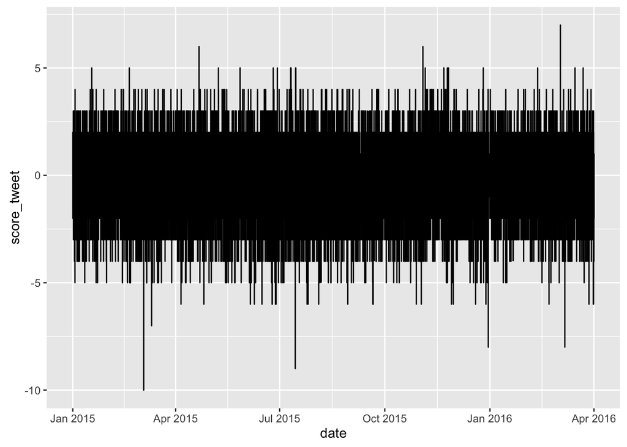

```r
ggplot(data=mb_sentiment_tweet, aes(x=date, y=score_tweet)) +
  geom_line()
```

However, with smoothing, ebbs and flows over time become clear. Though there is much variance day to day, smoothing reveals broad seasonal trends. Smoothing is appropriate for tweet volume and sentiment because the outcome is continuous.

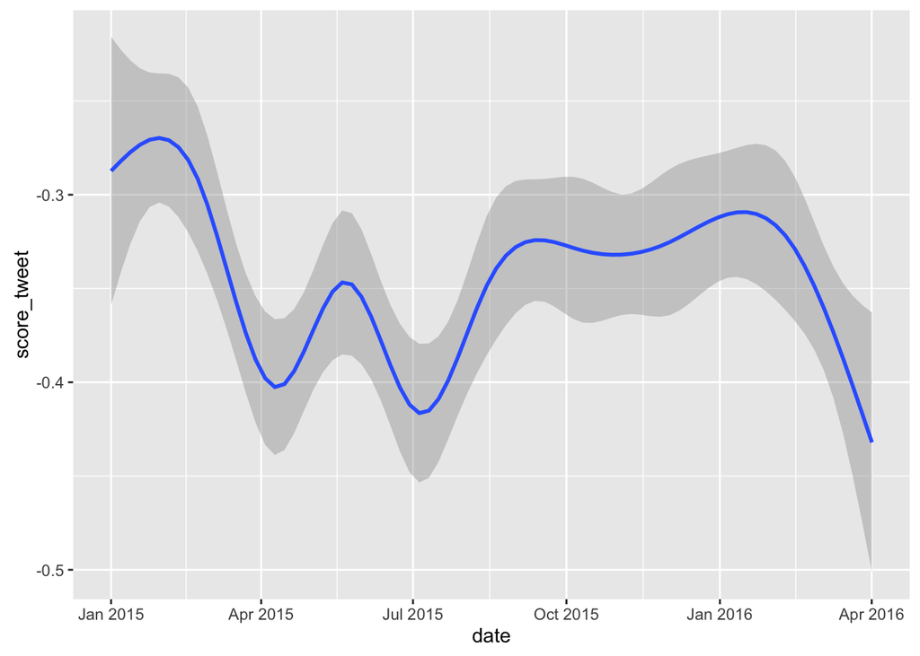

```r
options(digits = 3)
ggplot(data=mb_sentiment_tweet, aes(x=date, y=score_tweet)) +
  geom_smooth()
```

```r
options(digits = 22)
```

This chart shows the distribution of daily sentiment scores. The tweets of most days aired on the negative side, with few days boasting an average tweet score above 0.

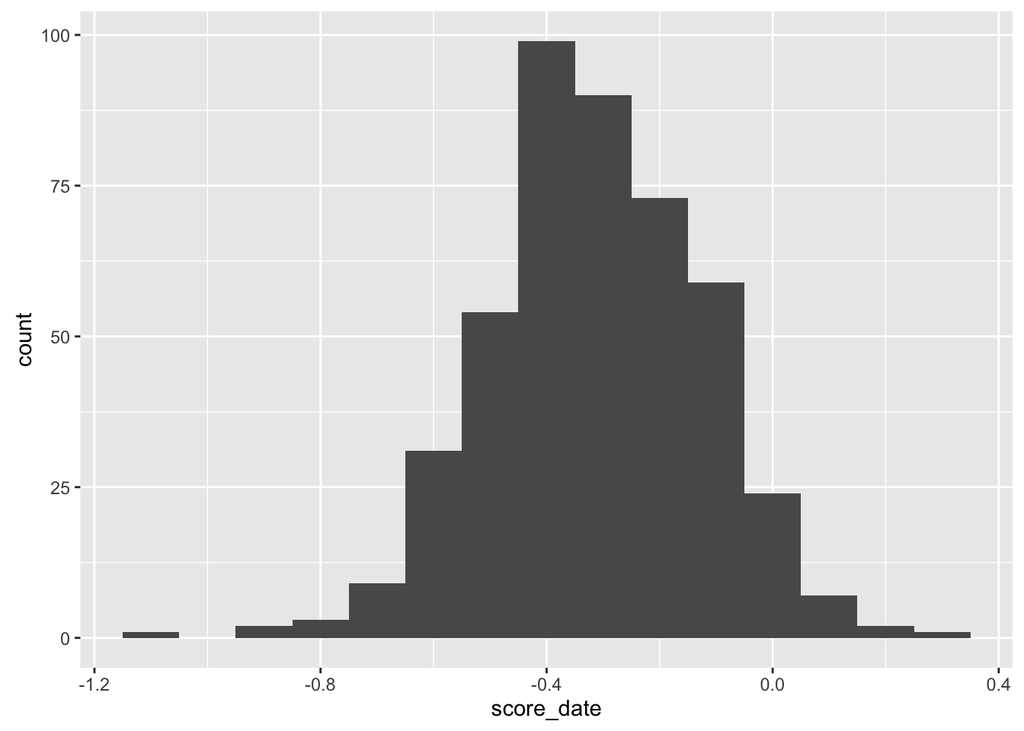

```r
options(digits = 3)
ggplot(data=mb_sentiment_date, aes(score_date)) +
  geom_histogram(binwidth = 0.1)
```

```r
options(digits = 22)
```

#### Visual Word Mapping

We built word clouds and word webs to convey the frequency and cooccurrance of words.

```r
#Postive and negative word data sets.
positives <- bing_megabus %>%
  filter(sentiment == "positive") %>%
  dplyr::select(word)

negatives = bing_megabus %>%
  filter(sentiment == "negative") %>%
  dplyr::select(word)

head(by_word)
```

```
## Source: local data frame [6 x 8]
##
##                   id                date    date2     time  weekend
##                (dbl)              (time)    (chr)    (chr)    (chr)
## 1 550802963749281792 2015-01-01 18:57:14 01-01-15 18:57:14 Thursday
## 2 550802963749281792 2015-01-01 18:57:14 01-01-15 18:57:14 Thursday
## 3 550802963749281792 2015-01-01 18:57:14 01-01-15 18:57:14 Thursday
## 4 550802963749281792 2015-01-01 18:57:14 01-01-15 18:57:14 Thursday
## 5 550802963749281792 2015-01-01 18:57:14 01-01-15 18:57:14 Thursday
## 6 550802963749281792 2015-01-01 18:57:14 01-01-15 18:57:14 Thursday
## Variables not shown: weekend_binary (dbl), month (chr), word (chr)
```

```r
word_list <- by_word %>% dplyr::select(word)
head(word_list)
```

```
## Source: local data frame [6 x 1]
##
##         word
##        (chr)
## 1 wlzkhallfa
## 2        let
## 3         me
## 4        fly
## 5        you
## 6  greyhound
```

```r
word_list_negatives <- subset(word_list, word %in% negatives$word)
head(word_list_negatives)
```

```
## Source: local data frame [6 x 1]
##
##       word
##      (chr)
## 1    smash
## 2  working
## 3 struggle
## 4  waiting
## 5    never
## 6     wait
```

```r
word_list_positives <- subset(word_list, word %in% positives$word)
head(word_list_positives)
```

```
## Source: local data frame [6 x 1]
##
##          word
##         (chr)
## 1        love
## 2        work
## 3 comfortable
## 4       saver
## 5        gold
## 6        good
```

```r
# Negative Word Cloud
word_list_negatives <- Corpus(VectorSource(word_list_negatives))
inspect(word_list_negatives)
```

```
## <<VCorpus>>
## Metadata:  corpus specific: 0, document level (indexed): 0
## Content:  documents: 1
##
## $word
## <<PlainTextDocument>>
## Metadata:  7
## Content:  chars: 295094
```

```r
toSpace <- content_transformer(function (x , pattern ) gsub(pattern, " ", x))
word_list_negatives <- tm_map(word_list_negatives, toSpace, "/")
word_list_negatives <- tm_map(word_list_negatives, toSpace, "@")
word_list_negatives <- tm_map(word_list_negatives, toSpace, "\\|")

#Build a term-document matrix
dtm <- TermDocumentMatrix(word_list_negatives)
m <- as.matrix(dtm)
v <- sort(rowSums(m),decreasing=TRUE)
d <- data.frame(word = names(v),freq=v)
head(d, 10)
```

```
##            word freq
## never     never 2382
## still     still 1658
## waiting waiting 1569
## shit       shit 1005
## fuck       fuck  960
## crash     crash  943
## fucking fucking  879
## bad         bad  855
## wait       wait  833
## worst     worst  830
```

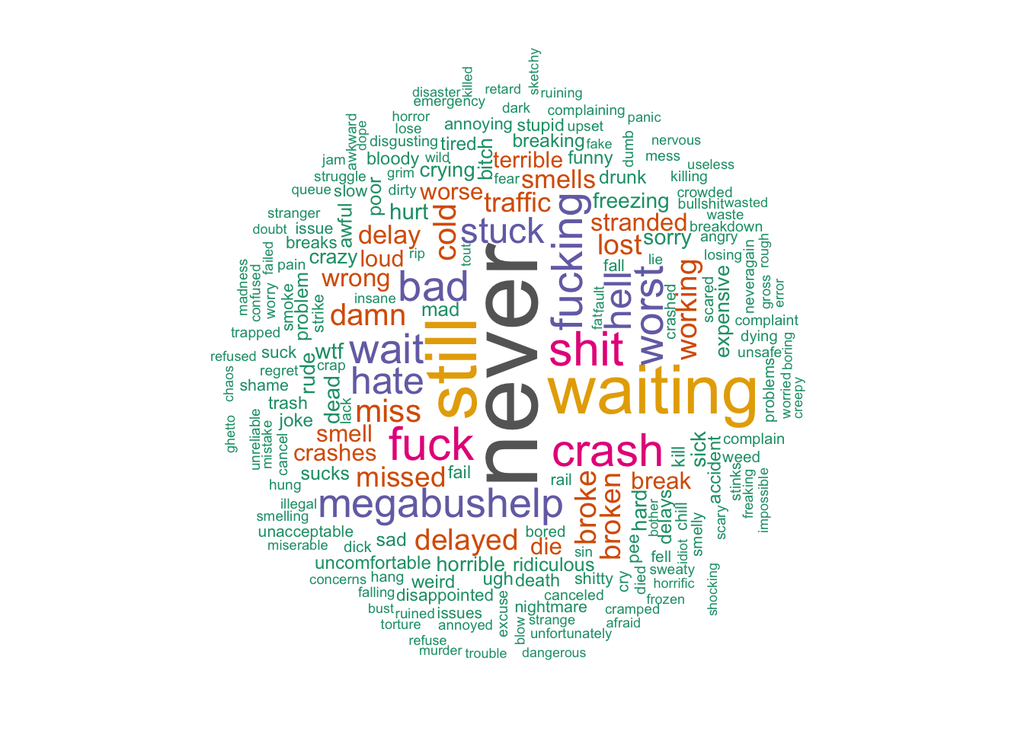

```r
# Word Cloud (Negative)
set.seed(1234)
wordcloud(words = d$word, freq = d$freq, min.freq = 1,
          max.words=200, random.order=FALSE, rot.per=0.35,
          colors=brewer.pal(8, "Dark2"))
```

```r
##### Positive Word Cloud #####
word_list_positives <- Corpus(VectorSource(word_list_positives))
#inspect(word_list_positives)

toSpace <- content_transformer(function (x , pattern ) gsub(pattern, " ", x))
word_list_positives <- tm_map(word_list_positives, toSpace, "/")
word_list_positives <- tm_map(word_list_positives, toSpace, "@")
word_list_positives <- tm_map(word_list_positives, toSpace, "\\|")
word_list_positives <- tm_map(word_list_positives, removeWords, c("megabus", "the", "and", "https", "you", "t.co", "for", "this", "bus", "that"))

#Build a term-document matrix
dtm <- TermDocumentMatrix(word_list_positives)
m <- as.matrix(dtm)
v <- sort(rowSums(m),decreasing=TRUE)
d <- data.frame(word = names(v),freq=v)
head(d, 10)
```

```
##          word freq
## good     good 1688
## right   right 1316
## love     love 1246
## work     work 1069
## cheap   cheap 1056
## better better 1017
## free     free  931
## well     well  889
## great   great  841
## gold     gold  768
```

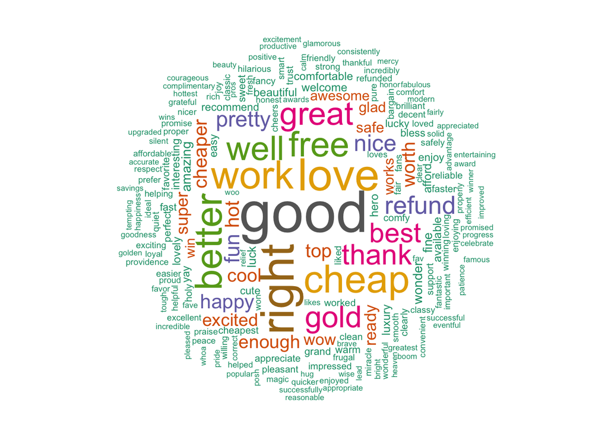

```r
# Word Cloud (Positive)
set.seed(1234)
wordcloud(words = d$word, freq = d$freq, min.freq = 1,
          max.words=200, random.order=FALSE, rot.per=0.35,
          colors=brewer.pal(8, "Dark2"))
```

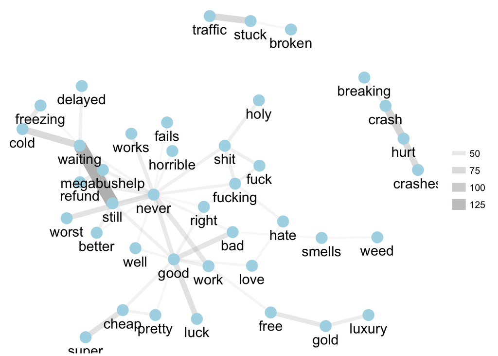

```r
# Word Cooccurence

word_cooccurences <- by_word %>% dplyr::select(word, id)
word_cooccurences <- subset(word_cooccurences, word %in% bing_megabus$word)

word_cooccurences <- word_cooccurences %>%
  pair_count(id, word, sort = TRUE) %>%
  dplyr::filter(n>25)

set.seed(2016)
word_cooccurences %>%
  filter(n >= 10) %>%
  graph_from_data_frame() %>%
  ggraph(layout = "fr") +
  geom_edge_link(aes(edge_alpha = n, edge_width = n), edge_colour="gray") +
  geom_node_point(color = "lightblue", size = 5) +
  geom_node_text(aes(label = name), vjust = 1.8, size=5) +
  theme_void()
```